# Mathieu Pont - Home Page

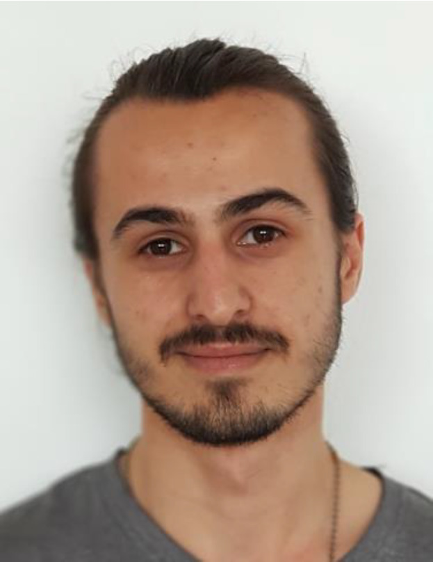

Mathieu Pont

RPTU Kaiserslautern-Landau

Scientific Visualization Lab

*[name].[surname][at]outlook.com*

### About

I currently have a post-doctoral position, since October 2024, at the RPTU Kaiserslautern-Landau in the [Scientific Visualization Lab](https://vis.cs.rptu.de/), working with [Christoph Garth](https://vis.cs.rptu.de/team/garth/).

Before that, I had a temporary post-doctoral position, that started in December 2023, at CNRS Sorbonne Université (LIP6) within the [TORI project](https://erc-tori.github.io/) with [Julien Tierny](https://julien-tierny.github.io/).

My thesis (from October 2020 to December 2023), supervised by [Julien Tierny](https://julien-tierny.github.io/), focused on the analysis of ensembles of scalar fields based on their merge trees or persistence diagrams using tools from Topological Data Analysis, with applications in feature tracking, data reduction, clustering and dimensionality reduction.

I did my master degree at Paris Descartes University (now Université Paris Cité) in the “Machine Learning for Data Science” track from 2018 to 2020.

[>>> Curriculum Vitae](https://mathieu-pont.github.io/docs/PONT_CV.pdf)

### Research

###### 2025

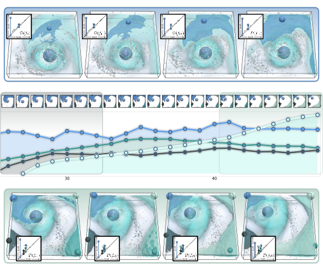

Region-Aware Wasserstein Distances of Persistence Diagrams  
and Merge Trees

Mathieu Pont and Christoph Garth

*IEEE Transactions on Visualization and Computer Graphics.*

Accepted, to be presented at IEEE VIS 2026

[Paper](https://arxiv.org/pdf/2510.16486) - [Code](https://github.com/MatPont/regionWasserstein) - Data

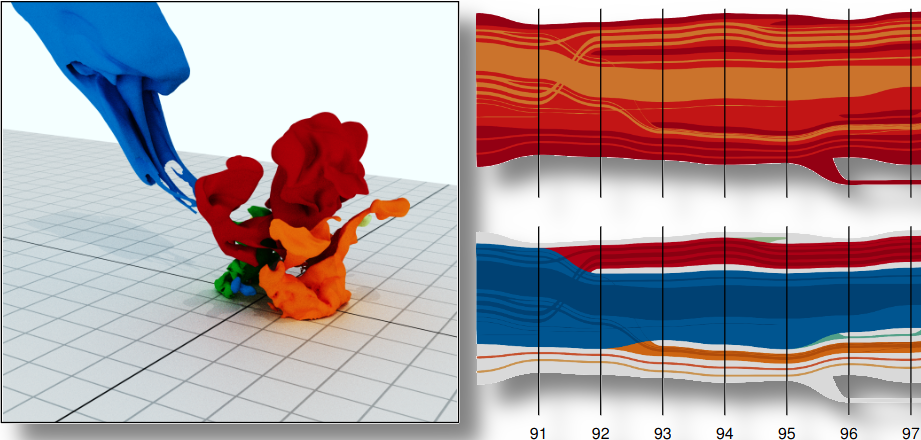

**A Taxonomy for Feature Tracking in Time-Varying Piecewise-Linear Scalar Fields**

Jonas Lukasczyk, Emma Nilsson, Florian Wetzels, Andrea Schnorr, Mathieu Pont, Ingrid Hotz, Ross Maciejewski, Julien Tierny and Christoph Garth

*IEEE Transactions on Visualization and Computer Graphics.*

Accepted.

###### 2024

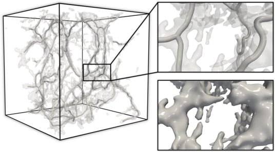

**A Practical Solver for Scalar Data Topological Simplification**

Mohamed Kissi, Mathieu Pont, Joshua A. Levine and Julien Tierny

*IEEE Transactions on Visualization and Computer Graphics.*

Proc. of IEEE VIS 2024.

[Paper](https://arxiv.org/pdf/2407.12399) - [Replicability Stamp](https://www.replicabilitystamp.org/index.html#https-github-com-mohamedkissi-code-paper-a-pratical-solver-for-scalar-data-topological-simplification)

###### 2023

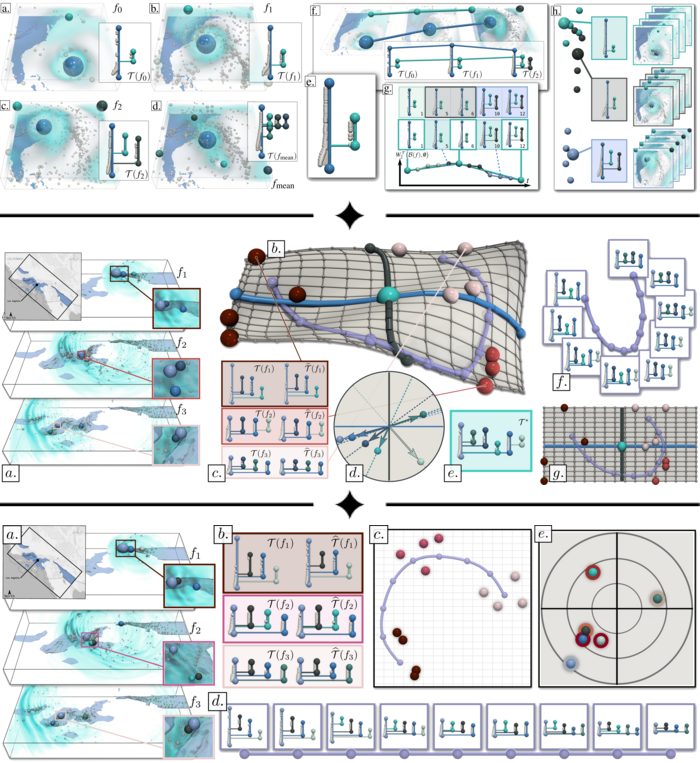

**Analysis of Ensembles of Topological Descriptors**

Mathieu Pont

*Ph.D. in Computer Science.*

*Committee:* Gabriel Peyré (President), David Coeurjolly (Reviewer), Vijay Natarajan (Reviewer), Elsa Cazelles (Examiner), Stanley Durrleman (Examiner), Roland Kwitt (Examiner), Katharine Turner (Examiner), Julien Tierny (Advisor)

[Manuscript](https://mathieu-pont.github.io/docs/manuscript.pdf) - [Manuscript (compressed)](https://mathieu-pont.github.io/docs/manuscript_compressed.pdf)

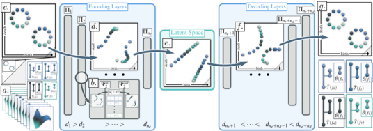

**Wasserstein Auto-Encoder of Merge Trees (and Persistence Diagrams)**

Mathieu Pont and Julien Tierny

*IEEE Transactions on Visualization and Computer Graphics.*

Presented at IEEE VIS 2024.

[Paper](https://arxiv.org/pdf/2307.02509.pdf) - [Code](https://github.com/MatPont/MT-WAE) - Data - [Replicability Stamp](https://www.replicabilitystamp.org/#https-github-com-matpont-mt-wae)

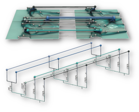

**Merge Tree Geodesics and Barycenters with Path Mappings**

Florian Wetzels, Mathieu Pont, Julien Tierny and Christoph Garth

*IEEE Transactions on Visualization and Computer Graphics.*

Proc. of IEEE VIS 2023.

**Best Paper Honorable Mention Award**

[Paper](https://arxiv.org/pdf/2308.03672) - [Code](https://github.com/vissubmission1463/ttk/)

###### 2022

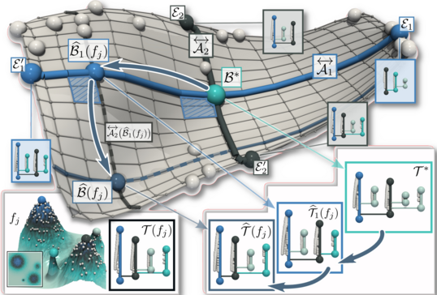

**Principal Geodesic Analysis of Merge Trees (and Persistence Diagrams)**

Mathieu Pont, Jules Vidal and Julien Tierny

*IEEE Transactions on Visualization and Computer Graphics.*

Presented at IEEE VIS 2023.

[Paper](https://arxiv.org/pdf/2207.10960.pdf) - [Code](https://github.com/MatPont/MT-PGA) - Data - [Replicability Stamp](http://www.replicabilitystamp.org/#https-github-com-matpont-mt-pga) - [Talk](https://www.youtube.com/watch?v=6CZKgVdEwn8)

###### 2021

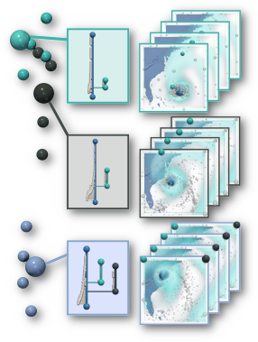

**Wasserstein Distances, Geodesics and Barycenters of Merge Trees**

Mathieu Pont, Jules Vidal, Julie Delon and Julien Tierny

*IEEE Transactions on Visualization and Computer Graphics.*

Proc. of IEEE VIS 2021.

[Paper](https://arxiv.org/pdf/2107.07789.pdf) - [Code](https://github.com/MatPont/WassersteinMergeTrees) - Data - [Replicability Stamp](http://www.replicabilitystamp.org/#https-github-com-matpont-wassersteinmergetrees) - [Talk](https://www.youtube.com/watch?v=M5fUzDpm3kY)

### Awards

##### 2023

- Best Paper Honorable Mention Award at [IEEE VIS 2023](http://ieeevis.org/year/2023/welcome)  
  *For the paper: “Merge Tree Geodesics and Barycenters with Path Mappings”*
- Best Paper and Presentation Award at [CORESA 2023](https://coresa2023.sciencesconf.org/)  
  *For the talk: “Analyse en Géodésiques Principales d’Arbres de Fusion (et de Diagrammes de Persistance)”*

### Talks

##### 2026

- Jul. 2nd, [ERC TORI Workshop Invited Talk](https://erc-tori.github.io/workshop/) – “Analysis of Ensembles of Topological Descriptors”

##### 2025

- Nov. 3rd, [IEEE VIS](https://ieeevis.org/year/2025/welcome) – “Tutorial: Merge Tree Computation and Feature Tracking in TTK”

##### 2024

- Nov. 21st, [CORESA](https://coresa2024.sciencesconf.org/) – “Poster: Wasserstein Auto-Encoders of Merge Trees (and Persistence Diagrams)”
- Oct. 17th, [IEEE VIS](http://ieeevis.org/year/2024/welcome) – “Wasserstein Auto-Encoders of Merge Trees (and Persistence Diagrams)”
- Jul. 1st, [RPTU Kaiserslautern-Landau Invited Talk](https://vis.cs.rptu.de/) – “Variability Analysis of Ensembles of Topological Descriptors”
- Jun. 18th, [Journée Visu](https://visu-24.sciencesconf.org/) – “Auto-Encodeurs de Wasserstein d’Arbres de Fusion (et de Diagrammes de Persistance)”
- May 30th, [Journée APR](https://www-apr.lip6.fr/web/doku.php?id=apr:journees:ete2024) – “Auto-Encodeurs de Wasserstein d’Arbres de Fusion (et de Diagrammes de Persistance)”

##### 2023

- Dec. 1st, Ph.D. Defense – “Analysis of Ensembles of Topological Descriptors”
- Oct. 26th, [IEEE VIS](http://ieeevis.org/year/2023/welcome) – “Principal Geodesic Analysis of Merge Trees (and Persistence Diagrams)”
- Oct. 22nd, [IEEE VIS](http://ieeevis.org/year/2023/welcome) – “Tutorial: Wasserstein Distances between Persistence Diagrams in TTK”
- Oct. 16th, [Pre-VIS Day](https://www.aviz.fr/Events/Previs2023) – “Principal Geodesic Analysis of Merge Trees (and Persistence Diagrams)”
- Jun. 23rd, [Journée APR](https://www-apr.lip6.fr/web/doku.php?id=apr:journees:ete2023) – “Analyse en Géodésiques Principales d’Arbres de Fusion (et de Diagrammes de Persistance)”
- Jun. 22nd, [Journée Visu](https://journee-visu.github.io/2023/) – “Analyse en Géodésiques Principales d’Arbres de Fusion (et de Diagrammes de Persistance)”
- Jun. 8th, [CORESA](https://coresa2023.sciencesconf.org/) – “Analyse en Géodésiques Principales d’Arbres de Fusion (et de Diagrammes de Persistance)”  
  *Best Paper and Presentation Award!*

##### 2022

- Nov. 25th, [JFIG](https://project.inria.fr/jfig2022/) – “Distances de Wasserstein, Géodésiques et Barycentres d’Arbres de Fusion”
- Oct. 17th, [IEEE VIS](http://ieeevis.org/year/2022/welcome) – “Tutorial: Wasserstein Distances, Barycenters and Clusters of Merge Trees in TTK” - [Talk](https://youtu.be/ny0kgoMbOfg?t=10755)
- Jun. 28th, [Journée Visu](https://journee-visu.github.io/2022/) – “Distances de Wasserstein, Géodésiques et Barycentres d’Arbres de Fusion”

##### 2021

- Oct. 28th, [IEEE VIS](http://ieeevis.org/year/2021/welcome) – “Wasserstein Distances, Geodesics and Barycenters of Merge Trees” - [Talk](https://www.youtube.com/watch?v=M5fUzDpm3kY)

### Teaching

##### 2022 - 2023

- [Elements de Programmation 1](http://licence.premiereannee.sorbonne-universite.fr/fr/la-licence-1ere-annee/liste-des-ue/lu1in001-element-de-programmation-i.html) - Licence 1 (Python) : ~20h TD, ~20h TP
- Structures de Données - Licence 2 (C) : ~20h TP

##### 2021 - 2022

- [Elements de Programmation 1](http://licence.premiereannee.sorbonne-universite.fr/fr/la-licence-1ere-annee/liste-des-ue/lu1in001-element-de-programmation-i.html) - Licence 1 (Python) : ~20h TD, ~20h TP
- [Introduction à la Visualisation Scientifique](https://julien-tierny.github.io/visualizationClass.html) - Master 2 (ParaView/C++) : ~20h TP

##### 2020 - 2021

- [Introduction à la Visualisation Scientifique](https://julien-tierny.github.io/visualizationClass.html) - Master 2 (ParaView/C++) : ~20h TP
- [Elements de Programmation 2](http://licence.premiereannee.sorbonne-universite.fr/fr/la-licence-1ere-annee/liste-des-ue/lu1in002-informatique-2.html) - Licence 1 (C) : ~40h TP